# Spam Emails Classification

Ming Ming Zhang

## Abstract

Given an email, we train a classifier to classify whether the email is spam or non-spam. In particular, we create a vocabulary list $\mathcal{L}$ using some standard techniques in text processing and convert each email into a feature vector $\vec{\,x} \in \mathbb{R}^{n}$ for the size $n$ of $\mathcal{L}$. Then we use logistic regression, neural networks and SVM to build spam filters.

The dataset is based on a subset of the [SpamAssassin Public Corpus](http://spamassassin.apache.org/old/publiccorpus), which has 6046 messages, with about a 31% spam ratio. Since the label is imbalanced, we will use $F_{1}$ score for the evaluation metric. The dataset is divided into 60% for training, 20% for cross validation and 20% for test. By using the cross validation set, we are able to determine the regularization parameters in all classifiers. The results are summarized by the following table.

```r
res = data.frame(Model=c("Logistic regression", "Neural networks with 5 units", "SVM with linear kernel"),
                 "Regularized Parameter"=c(0, 0, 1),
                 Threshold=c("0.5", "NA", "NA"),
                 Precision=c(0.971, 1, 0.959),
                 Recall=c(0.964, 1, 0.972),
                 F1=c(0.968, 1, 0.965))
res
```

| Model | Regularized.Parameter | Threshold | Precision | Recall | F1 |
| --- | --- | --- | --- | --- | --- |
| Logistic regression | 0 | 0.5 | 0.971 | 0.964 | 0.968 |
| Neural networks with 5 units | 0 | NA | 1.000 | 1.000 | 1.000 |
| SVM with linear kernel | 1 | NA | 0.959 | 0.972 | 0.965 |

At the end, we inspect the top predictive words for spam classified by logistic regression and SVM, respectively. Interestingly, they are quite different.

Note that we only consider the body of the email, excluding the email headers. All text preprocessing and ML algorithms mentioned here are implemented in R, except SVM applied from `e1071` package.

## Vocabulary List

The dataset $\mathcal{D}$ contains $6046$ emails, with about a $31\%$ spam ratio; in particular, it contains `spam`, `easy_ham`, `hard_ham`, `easy_ham_2` and `spam_2` from [SpamAssassin Public Corpus](http://spamassassin.apache.org/old/publiccorpus). We exclude the email hearders and only use the body of the email. We preprocess each email from $\mathcal{D}$ and obtain the dataset $\mathcal{PD}$ using the following methods: removal of non-graphical characters, lower-casing, removal of HTML tags, normalizing URLs to “httpaddr”, normalizing email addresses to “emailaddr”, normalizing dollar signs to “dollar”, removal of punctuation, removal of non-alphanumeric characters, normalizing numbers to “number”, removal of stop words, word stemming, removal of white spaces, and removal of empty lines.

```r
library(tm)
D = VCorpus(DirSource("~/Downloads/Data/SpamClassification/emails"))
# Preprocess the corpus of emails using the function `processText`.
PD = tm_map(D, content_transformer(processText))
# Count the number of appearance for each word of preprocessed emails.
dtm = DocumentTermMatrix(PD)
W = colSums(as.matrix(dtm))
# The vocabulary list contains 1662 words such that each word appeares at least 100 times.
freqWords = W[W>100]
L = names(freqWords)
```

```r
head(L)
```

```
[1] "aaaaaaaaaaaaaaaaaaaaaaaaaaaaaaaaaaaaaaaaaaaaaaaaaaaaaaaaaaaaaaaaaaaaaaaaaaaa"
[2] "abil"
[3] "abl"
[4] "absolut"
[5] "abus"
[6] "accept"
```

We provide an example illustrating the preprocessing step.

```r
spams1 = VCorpus(DirSource("~/Downloads/Data/SpamClassification/spam"))
spams2 = VCorpus(DirSource("~/Downloads/Data/SpamClassification/spam_2"))
emails1 = VCorpus(DirSource("~/Downloads/Data/SpamClassification/easy_ham"))
emails2 = VCorpus(DirSource("~/Downloads/Data/SpamClassification/easy_ham_2"))
emails3 = VCorpus(DirSource("~/Downloads/Data/SpamClassification/hard_ham"))
```

An email from $\mathcal{D}$:

```r
inspect(spams1[[3]])
```

```
<<PlainTextDocument>>
Metadata:  7
Content:  chars: 2033

From sabrina@mx3.1premio.com  Thu Aug 22 14:44:07 2002
Return-Path: <sabrina@mx3.1premio.com>
Delivered-To: zzzz@localhost.spamassassin.taint.org
Received: from localhost (localhost [127.0.0.1])
    by phobos.labs.spamassassin.taint.org (Postfix) with ESMTP id 1E90847C66
    for <zzzz@localhost>; Thu, 22 Aug 2002 09:44:02 -0400 (EDT)
Received: from mail.webnote.net [193.120.211.219]
    by localhost with POP3 (fetchmail-5.9.0)
    for zzzz@localhost (single-drop); Thu, 22 Aug 2002 14:44:03 +0100 (IST)
Received: from email.qves.com (email1.qves.net [209.63.151.251] (may be forged))
    by webnote.net (8.9.3/8.9.3) with ESMTP id OAA04953
    for <zzzz@spamassassin.taint.org>; Thu, 22 Aug 2002 14:37:23 +0100
Received: from qvp0086 ([169.254.6.17]) by email.qves.com with Microsoft SMTPSVC(5.0.2195.2966);
     Thu, 22 Aug 2002 07:36:20 -0600
From: "Slim Down" <sabrina@mx3.1premio.com>
To: <zzzz@spamassassin.taint.org>
Subject: Guaranteed to lose 10-12 lbs in 30 days                          11.150
Date: Thu, 22 Aug 2002 07:36:19 -0600
Message-ID: <9a63c01c249e0$e5a9d610$1106fea9@freeyankeedom.com>
MIME-Version: 1.0
Content-Type: text/plain;
    charset="iso-8859-1"
Content-Transfer-Encoding: 7bit
X-Mailer: Microsoft CDO for Windows 2000
Thread-Index: AcJJ4OWpowGq7rdNSwCz5HE3x9ZZDQ==
Content-Class: urn:content-classes:message
X-MimeOLE: Produced By Microsoft MimeOLE V6.00.2462.0000
X-OriginalArrivalTime: 22 Aug 2002 13:36:20.0969 (UTC) FILETIME=[E692FD90:01C249E0]

1) Fight The Risk of Cancer!
http://www.adclick.ws/p.cfm?o=315&s=pk007

2) Slim Down - Guaranteed to lose 10-12 lbs in 30 days
http://www.adclick.ws/p.cfm?o=249&s=pk007

3) Get the Child Support You Deserve - Free Legal Advice
```

[output cut: 11 more lines]

```













If you wish to leave this list please use the link below.
http://www.qves.com/trim/?zzzz@spamassassin.taint.org%7C17%7C308417
```

The one in $\mathcal{PD}$ (after proprecessing):

```r
processText(spams1[[3]]$content)
```

```
 [1] "number fight risk cancer"                         "httpaddr"
 [3] "number slim guarante lose number lbs number day"  "httpaddr"
 [5] "number get child support deserv free legal advic" "httpaddr"
 [7] "number join web fastest grow singl communiti"     "httpaddr"
 [9] "number start privat photo album onlin"            "httpaddr"
[11] "wonder day"                                       "offer manag"
[13] "prizemama"                                        "wish leav list pleas use link"
[15] "httpaddr"
```

Note that $\mathcal{PD}$ consists of preprocessed words. Then we can create a vocabulary list
$$\mathcal{L} = \{w \in \mathcal{PD} \;|\; \alpha(w) > 100\},$$
where $\alpha$ counts the number of appearance. The number of words in $\mathcal{L}$, denoted by $n$, is 1662. The most frequent 100 words in $\mathcal{L}$ is showed below.

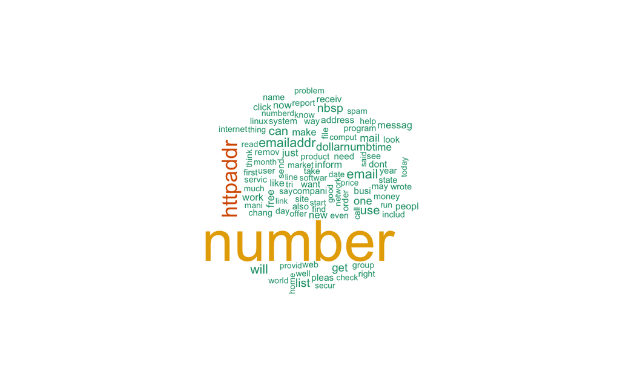

```r
set.seed(123)
# Show the top 100 frequent words in `vocabList`.
library(RColorBrewer)
library(wordcloud)
dark2 <- brewer.pal(6, "Dark2")
wordcloud(names(W), W, max.words=100, colors=dark2)
```

## Extracting Features

Let $X \in \mathbb{F}^{m\times n}$ be the feature matrix such that $\mathbb{F} = \{0,1\}$, $m$ is the number of emails in $\mathcal{D}$ and $n$ is the number of words in $\mathcal{L}$. Denote by $1$ if the word of email in $\mathcal{PD}$ is in $\mathcal{L}$, $0$ otherwise. Recall that $m = 6046$ and $n = 1662$. Let $\vec{\,y} \in \mathbb{F}^{m}$ be the label vector corresponding to each email, where $1$ means spam and $0$ is non-spam.

```r
# Denote by the lable 1 spam for spams1 and spams2 and by 0 non-spam for emails1, emails2, emails3.
featureText1 = function(txt) featureText(txt, txtList=L)
PD1 = tm_map(emails1, content_transformer(featureText1))
X1 = getFeatureMatrix(PD1, L)
Y1 = rep(0, nrow(X1))
XY1 = cbind(X1, Y1)
PD2 = tm_map(emails2, content_transformer(featureText1))
X2 = getFeatureMatrix(PD2, L)
Y2 = rep(0, nrow(X2))
XY2 = cbind(X2, Y2)
PD3 = tm_map(emails3, content_transformer(featureText1))
X3 = getFeatureMatrix(PD3, L)
Y3 = rep(0, nrow(X3))
XY3 = cbind(X3, Y3)
PD4 = tm_map(spams1, content_transformer(featureText1))
X4 = getFeatureMatrix(PD4, L)
Y4 = rep(1, nrow(X4))
XY4 = cbind(X4, Y4)
PD5 = tm_map(spams2, content_transformer(featureText1))
X5 = getFeatureMatrix(PD5, L)
Y5 = rep(1, nrow(X5))
XY5 = cbind(X5, Y5)
# Augmented matrix XY
XY = rbind(XY1, XY2, XY3, XY4, XY5)
colnames(XY) = NULL
# Shuffle XY
set.seed(123)
idx = sample(1:nrow(XY))
XY = XY[idx,]
```

```r
dim(XY)
```

```
[1] 6046 1663
```

```r
table(XY[,ncol(XY)])
```

```
   0    1
4150 1896
```

```r
paste("The ratio", table(XY[,ncol(XY)])[2]/sum(table(XY[,ncol(XY)])))
```

```
[1] "The ratio 0.313595765795567"
```

## Analysis

Since the problem is supervised learning, we will use logistic regression, neural networks and SVM to build the spam filters. We divide the dataset into $60\%$ for training, $20\%$ for cross-validation and $20\%$ for test set.

```r
# Divide the dataset
ratioTrain = 0.6
ratioVal = 0.2
ratioTest = 0.2
XY_train = splitData(XY, ratioTrain, ratioVal, ratioTest)[[1]]
X_train = XY_train[,-ncol(XY)]
y_train = XY_train[,ncol(XY)]
XY_val = splitData(XY, ratioTrain, ratioVal, ratioTest)[[2]]
X_val = XY_val[,-ncol(XY)]
y_val = XY_val[,ncol(XY)]
XY_test = splitData(XY, ratioTrain, ratioVal, ratioTest)[[3]]
X_test = XY_test[,-ncol(XY)]
y_test = XY_test[,ncol(XY)]
```

### Logistic Regression

The logistic regression $h$ with regularization is implemented, where regularization parameter is denoted by $\lambda$. Let $n$ be the number of features. The cost function on $\vec{\,\theta} \in \mathbb{R}^{n}$ is defined by
$$J(\vec{\,\theta}) = \frac{1}{m}[-\vec{\,y}\cdot\log{(h)} - (1-\vec{\,y})\cdot\log{(1-h)}] + \frac{\lambda}{2m}(\vec{\,\theta}\cdot\vec{\,\theta}),$$
where $m$ is the number of training examples and $\vec{\,y} \in \mathbb{R}^{m}$ is the label vector. In the implementation, we use the conjugate gradient method to optimize $J(\vec{\,\theta})$.

The following learning curve shows low bias.

```
$error_train
[1] 0.000000000 0.002427184 0.005046864 0.005102041

$error_val
[1] 0.06544503 0.03761349 0.03598972 0.02960103

$figure
```

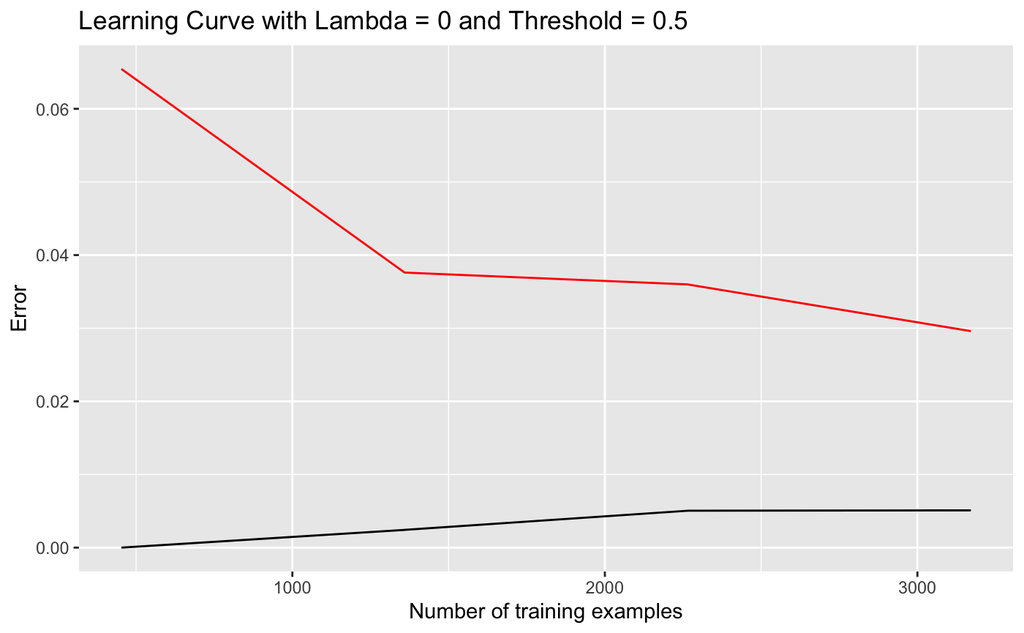

```r
lambda = 0
maxit = 100
epsilon = 0.5
learningCurve(X_train, y_train, X_val, y_val, lambda, maxit, epsilon)
```

```
$error_train
 [1] 0.008108108 0.008108108 0.008562416 0.008562416 0.008562416 0.008562416 0.008562416 0.008562416 0.009025271
[10] 0.009025271 0.011286682 0.016734509

$error_val
 [1] 0.03092784 0.03092784 0.03092784 0.03092784 0.03092784 0.03092784 0.03225806 0.03225806 0.03225806 0.03092784
[11] 0.03242542 0.03108808

$figure
```

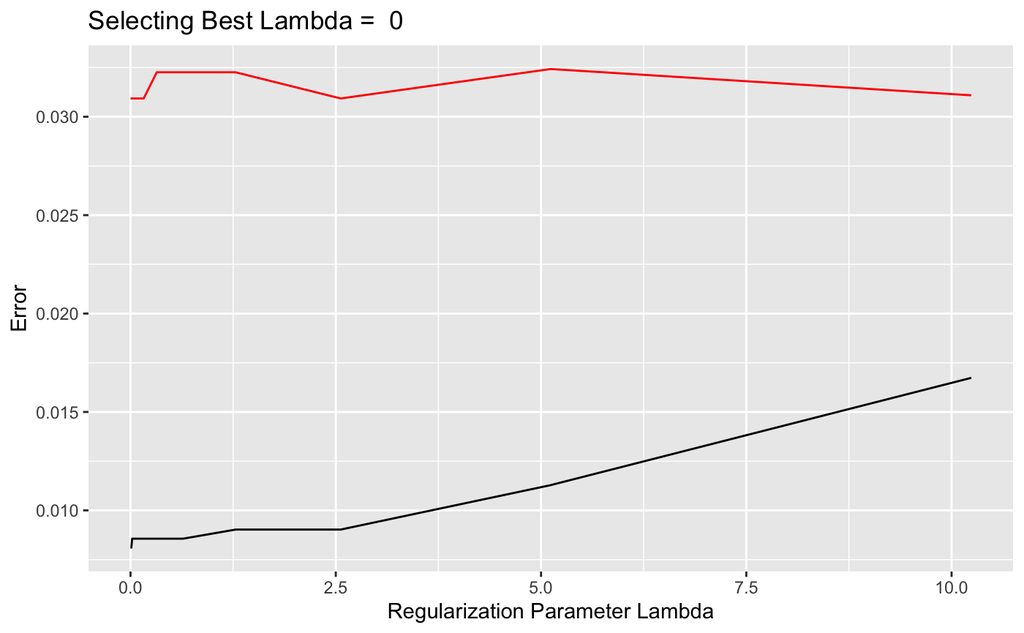

```r
lambda_vec = c(0,0.01,0.02,0.04,0.08,0.16,0.32,0.64,1.28,2.56,5.12,10.24)
maxit = 100
epsilon = 0.5
selectLambda(X_train, y_train, X_val, y_val, lambda_vec, maxit, epsilon)
```

```r
lambda = 0
maxit = 400
modelLog = logLearning(X_train, y_train, lambda, maxit)
theta = modelLog$par
epsilon = 0.5
F1(y_test, logPredict(X_test, theta, epsilon))
```

```
$precision
[1] 0.9714286

$recall
[1] 0.9639175

$F1
[1] 0.9676585
```

```r
paste("Logistic regression with Lambda=0 and threshold=0.5:", F1(y_test, logPredict(X_test, theta, epsilon))[[3]])
```

```
[1] "Logistic regression with Lambda=0 and threshold=0.5: 0.967658473479948"
```

### Neural Networks

We also implement single hidden layer neural networks $h$ with regularization, where $\lambda$ is the regularization parameter. The cost function is defined by
$$\frac{1}{m}\sum_{k=1}^{K}[-\vec{y_{k}}\cdot\log(h_{k}) - (1-\vec{y_{k}})\cdot\log(1-h_{k})] + \frac{\lambda}{2m}[\sum_{i=1}^{s_{1}}\sum_{j=1}^{n}(\Theta_{i,j}^{1})^{2} + \sum_{i=1}^{s_{2}}\sum_{j=1}^{s_{1}}(\Theta_{i,j}^{2})^{2}],$$
where $m$ is the number of examples, $n$ is the number of features, $K$ is the number of labels, $\vec{y_{k}} \in \{0,1\}^{K}$ is an elementary vector, $h_{k} \in \mathbb{R}^{m}$ is the $k$-th output unit, $s_{1}, s_{2}$ are the number of units in the hidden layer and output layer, respectively, and $\Theta^{1} \in \mathbb{R}^{s_1\times n}, \Theta^{2} \in \mathbb{R}^{s_2\times s_1}$ are learning parameter matrices. The backpropagation method and the conjugate gradient method are used for finding paritial derivatives of the cost function and optimazation, respectively.

The following learning curve for the 5 units single hidden layer neural networks without regularization indicates a prefect fit.

```
$error_train
[1] 0 0 0 0

$error_val
[1] 0 0 0 0

$figure
```

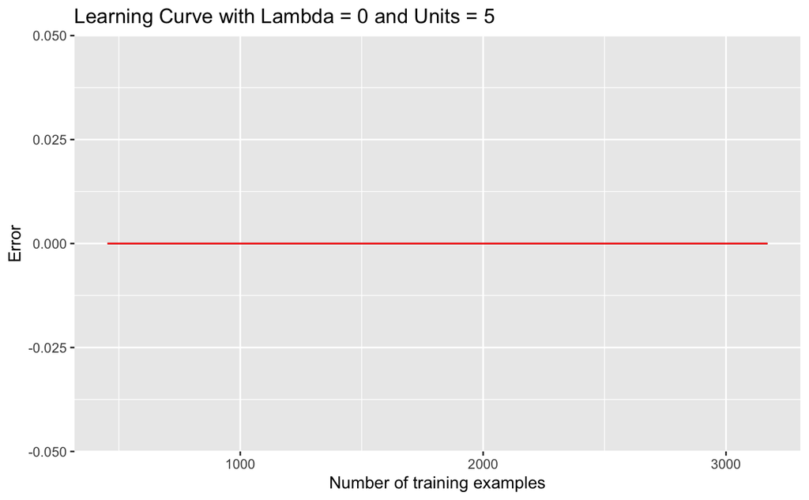

```r
lambda = 0
maxit = 100
epsilon = 0.5
hidden_layer_size = 5
num_labels = 2
learningCurve(X_train, y_train+1, X_val, y_val+1, lambda, maxit, epsilon, hidden_layer_size, num_labels)
```

```r
hidden_layer_size = 5
num_labels = 2
lambda = 0
maxit = 100
modelNNet = nnLearning(input_layer_size=ncol(X_train), hidden_layer_size, num_labels, X_train, y_train+1, lambda, maxit)
Theta1 = modelNNet$Theta1
Theta2 = modelNNet$Theta2
nn_params = c(t(Theta1), t(Theta2))
F1(y_test+1, predictNN(Theta1, Theta2, X_test))
```

```
$precision
[1] 1

$recall
[1] 1

$F1
[1] 1
```

```r
paste("NNet with 5 Units and Lambda=0:", F1(y_test+1, predictNN(Theta1, Theta2, X_test))[[3]])
```

```
[1] "NNet with 5 Units and Lambda=0: 1"
```

### SVM

We apply SVM from `e1071` package with linear kernel using the regularization parameter $C=1$. It is possible to get higher $F_{1}$ score by training the SVM for other constant $C$.

```r
library(e1071)
kernel = "linear"
cost = 1
modelSVM = svm(X_train, y_train, scale=F, kernel, cost, type = "C-classification")
thetaSVM = coef(modelSVM)
F1(y_test, predict(modelSVM, X_test))
```

```
$precision
[1] 0.9592875

$recall
[1] 0.9716495

$F1
[1] 0.9654289
```

```r
paste("SVM with linear kernel and C=1:", F1(y_test, predict(modelSVM, X_test))[[3]])
```

```
[1] "SVM with linear kernel and C=1: 0.965428937259923"
```

## Top Predictors for Spam

We inspect the top predictive words for spam classified by logistic regression and SVM, respectively.

```r
thetaLog = theta[-1]
names(thetaLog) = 1:length(thetaLog)
logP = names(sort(thetaLog[thetaLog>0], decreasing=T)[1:20])
L[as.numeric(logP)]
```

```
 [1] "basenumb"                          "click"                             "spamassassinsight"
 [4] "remov"                             "deathtospamdeathtospamdeathtospam" "pleas"
 [7] "guarante"                          "visit"                             "contenttransferencod"
[10] "price"                             "dollarnumb"                        "offer"
[13] "credit"                            "contenttyp"                        "dollar"
[16] "websit"                            "market"                            "order"
[19] "week"                              "internet"
```

```r
thetaSVM = thetaSVM[-1]
names(thetaSVM) = 1:length(thetaSVM)
svmP = names(sort(thetaSVM[thetaSVM>0], decreasing=T)[1:20])
L[as.numeric(svmP)]
```

```
 [1] "insur"             "kid"               "spamassassinsight" "told"              "rpm"
 [6] "wrong"             "toner"             "august"            "xml"               "principl"
[11] "browser"           "daili"             "datapow"           "upon"              "razor"
[16] "perform"           "submit"            "figur"             "murphi"            "command"
```